# Tarea 2 - Algoritmos de Aprendizaje No Supervisado

Humberto Alexander de la Cruz - 23735, Daniel Oswaldo Juarez Herrera - 23709, Dilary Cruz - 231010

2026-02-25

Link de github: https://github.com/hadelacruz/Algoritmos-Aprendizaje-No-Supervisado.git

## Introducción

El aprendizaje no supervisado constituye una de las principales ramas del aprendizaje automático y se enfoca en el análisis de datos sin etiquetas previamente definidas. A diferencia del aprendizaje supervisado, donde el modelo aprende a partir de pares entrada y salida, en el aprendizaje no supervisado el objetivo es descubrir estructuras internas, patrones latentes o representaciones comprimidas de los datos.

Entre sus aplicaciones más relevantes se encuentran la reducción de dimensionalidad, la visualización de datos de alta dimensión, la detección de estructuras ocultas y la extracción de características. Estos métodos permiten comprender mejor la información contenida en grandes volúmenes de datos, facilitando tareas posteriores como clasificación, agrupamiento o sistemas de recomendación.

## Objetivos

1. Profundizar el funcionamiento matemático y conceptual de los algoritmos SVD, t-SNE, UMAP e ICA.
2. Analizar sus principales usos y aplicaciones en problemas reales.
3. Implementar cada algoritmo utilizando conjuntos de datos específicos.

# 2.1 Singular Value Decomposition (SVD)

Consideramos la Descomposición en Valores Singulares (SVD) es un método de factorización matricial ampliamente utilizado en álgebra lineal y aprendizaje automático. Este método permite descomponer cualquier matriz en tres componentes fundamentales que capturan su estructura geométrica y algebraica interna.

SVD identifica las direcciones principales de variación en los datos, permitiendo representar la información en un espacio de menor dimensión sin perder la mayor cantidad posible de información. Esto permite representar la información original mediante un número reducido de componentes, conservando la mayor cantidad posible de información relevante.

## 1. Objetivo

El objetivo de esta sección es aplicar el algoritmo de Descomposición en Valores Singulares (SVD) al dataset MovieLens 100K para identificar factores latentes en la matriz usuario–película y comprender cuándo y por qué se utiliza este algoritmo en sistemas de recomendación.

SVD se utiliza principalmente cuando:

- Se trabaja con matrices grandes y dispersas.
- Se desea reducir dimensionalidad.
- Se buscan patrones latentes no observables directamente.
- Se necesita modelar relaciones implícitas entre usuarios y productos.

## 2. Descripción del Dataset

Se utiliza el dataset MovieLens 100K, el cual contiene:

- 100,000 calificaciones
- 943 usuarios
- 1682 películas
- Calificaciones en escala de 1 a 5

Cada registro contiene:

- ID del usuario
- ID de la película
- Calificación
- Timestamp

Este tipo de dataset es altamente disperso, ya que cada usuario solo califica una pequeña fracción del total de películas disponibles.

## 3. Implementación

```
## Dimensión de la matriz: 943 1682
```

```
## Nivel de dispersión (sparsity): 0.9369533
```

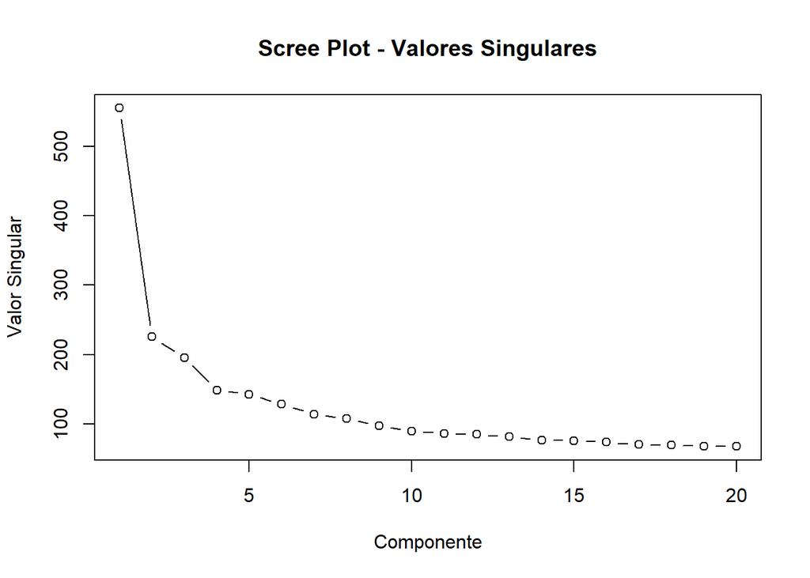

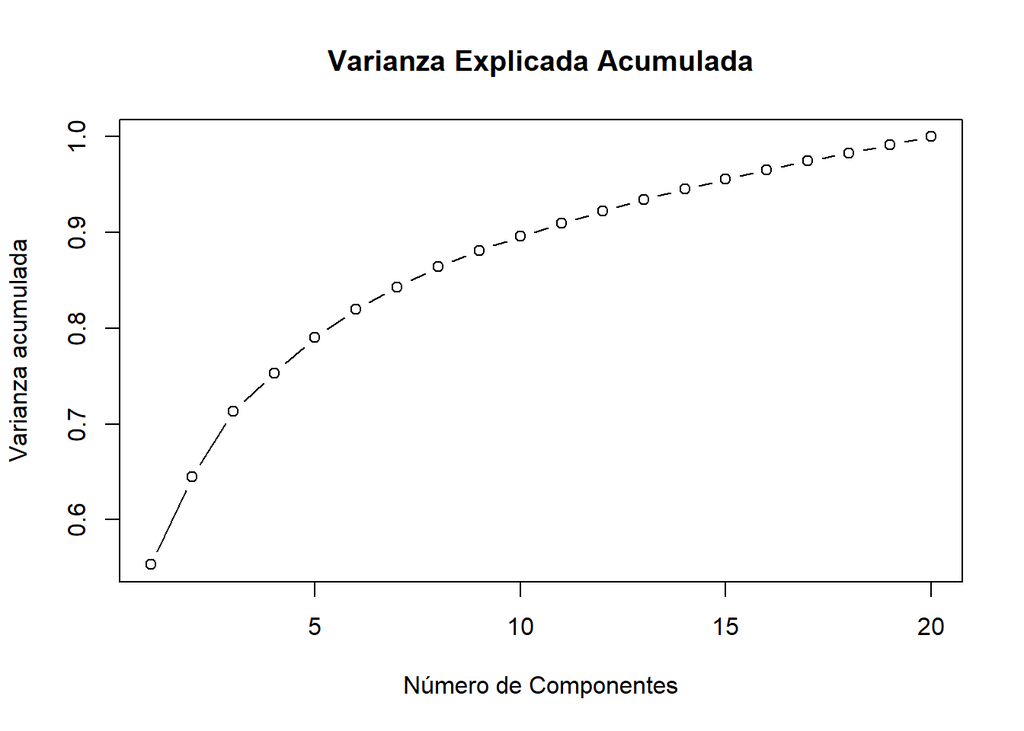

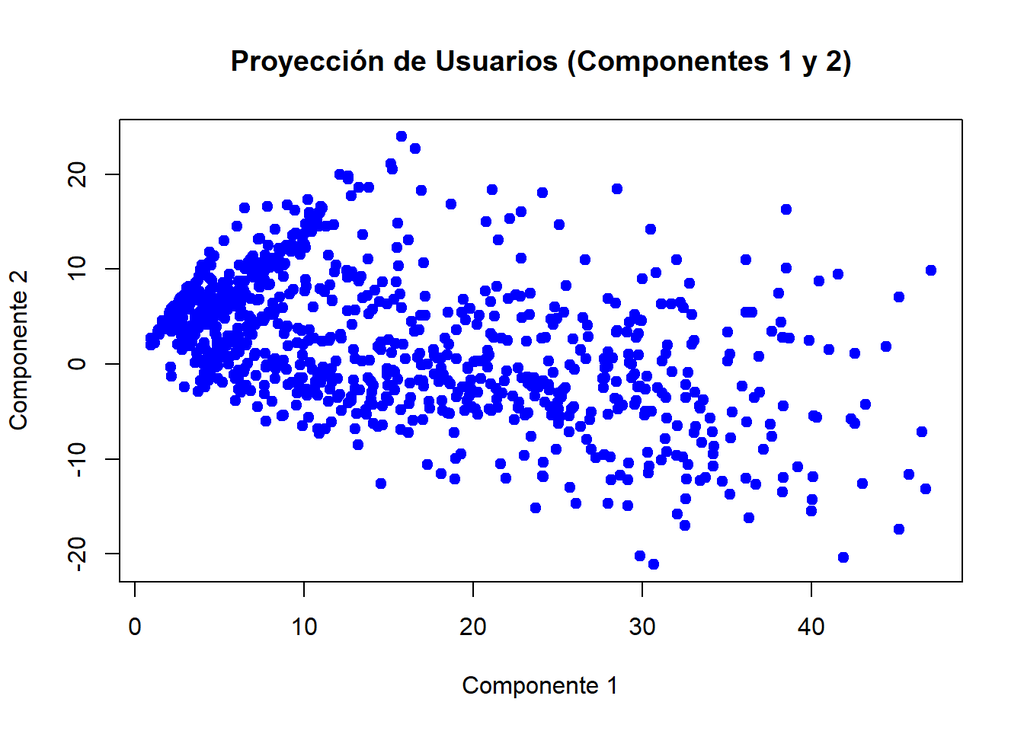

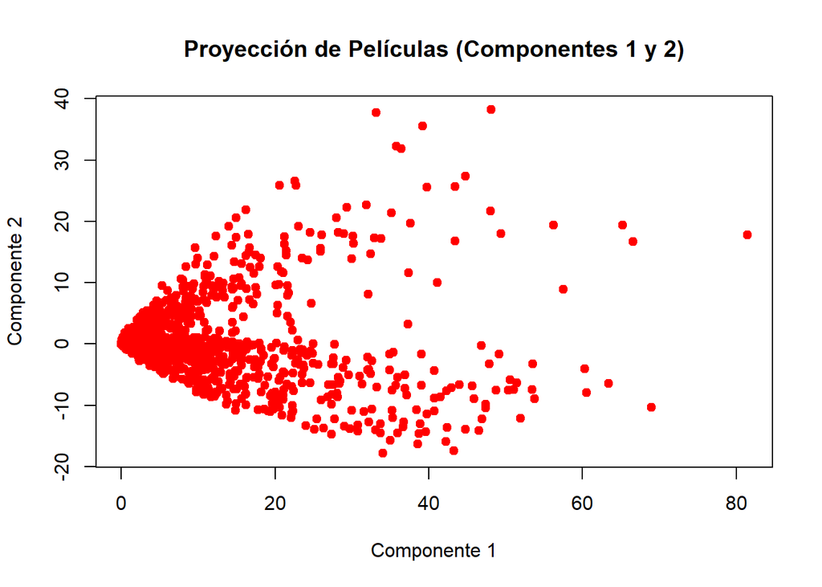

## 4. Decisiones Metodológicas

### Preprocesamiento

Se realizó un centrado por usuario restando el promedio de calificación individual.  
Esto elimina sesgos personales (usuarios que siempre califican alto o bajo) y permite que SVD capture patrones relativos de preferencia.

### Selección del parámetro k

Se eligieron 20 componentes porque:

- Los primeros componentes concentran la mayor parte de la varianza.
- Permiten reducir dimensionalidad significativamente.
- Evitan complejidad innecesaria.

## 5. Interpretación de Resultados

- El Scree Plot muestra una caída pronunciada en los primeros componentes, indicando que concentran la mayor parte de la estructura del sistema.
- La varianza acumulada demuestra que con pocos componentes se explica la mayor parte de la información.
- La proyección de usuarios evidencia similitudes y diferencias en patrones de calificación.
- La proyección de películas revela agrupamientos implícitos basados en comportamiento de valoración.

## 6. Conclusión

La aplicación de SVD al dataset MovieLens 100K permitió identificar factores latentes en las preferencias de los usuarios.

Se confirmó que:

- La matriz es altamente dispersa.
- Un número reducido de componentes captura la mayor parte de la información.
- Es posible representar usuarios y películas en un espacio reducido conservando la estructura principal.

# 2.2 t-SNE – Breast Cancer Wisconsin (Diagnostic) Dataset

El algoritmo t-SNE es un método no lineal de reducción de dimensionalidad diseñado principalmente para la visualización de datos de alta dimensión en espacios de dos o tres dimensiones. Fue propuesto por van der Maaten y Hinton (2008) como una mejora del algoritmo SNE (Stochastic Neighbor Embedding).

A diferencia de técnicas como PCA o SVD, que buscan maximizar la varianza global, t-SNE se enfoca en preservar la estructura local del conjunto de datos.

## 1. Objetivo

El objetivo de esta sección es aplicar el algoritmo t-SNE (t-Distributed Stochastic Neighbor Embedding) al dataset Breast Cancer Wisconsin (Diagnostic) para analizar su capacidad de reducción de dimensionalidad y visualización de estructuras no lineales en datos médicos.

t-SNE se utiliza principalmente cuando:

- Se desea visualizar datos de alta dimensión en 2D o 3D.
- Se buscan agrupamientos naturales.
- Se sospechan relaciones no lineales entre variables.
- Se quiere evaluar separabilidad entre clases.

## 2. Descripción del Dataset

El dataset Breast Cancer Wisconsin (Diagnostic) contiene:

- 569 observaciones
- 30 variables numéricas (características extraídas de imágenes celulares)
- 1 variable de diagnóstico:
  - M = Maligno
  - B = Benigno

Las variables representan medidas como radio, textura, perímetro, área y suavidad de células tumorales.

## 3. Implementación

```
## [1] 0
```

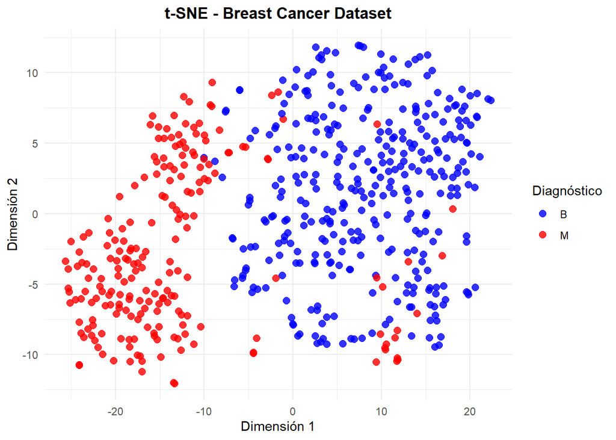

## 4. Decisiones Metodológicas

### Eliminación de la columna id

La variable id no contiene información clínica relevante, por lo que se elimina antes del análisis.

### Escalado de variables

t-SNE es sensible a la escala de los datos.  
Se aplicó estandarización (media 0, desviación estándar 1) para evitar que variables con mayor magnitud dominen la estructura.

### Selección de parámetros

- dims = 2 → para visualización en plano.
- perplexity = 30 → valor común para datasets de tamaño medio (569 observaciones).
- max_iter = 1000 → suficiente para convergencia estable.
- set.seed() → reproducibilidad.

## 5. Interpretación del Resultado

El gráfico muestra la proyección bidimensional generada por t-SNE.

Si se observan dos agrupamientos diferenciados entre M y B, esto indica que:

- El dataset posee estructura interna clara.
- Las variables permiten distinguir entre tumores malignos y benignos.
- Existen relaciones no lineales capturadas correctamente por t-SNE.

A diferencia de SVD, t-SNE no busca maximizar varianza global, sino preservar vecindades locales.

## 6. Conclusión

La aplicación de t-SNE al dataset Breast Cancer Wisconsin permitió visualizar la estructura interna de los datos en dos dimensiones.

Se observó que el algoritmo:

- Preserva relaciones locales entre observaciones.
- Permite identificar agrupamientos naturales.
- Es altamente efectivo para visualización exploratoria.

t-SNE es especialmente útil para análisis exploratorio en datasets complejos con múltiples variables y posibles relaciones no lineales.

# 2.3 UMAP – Uniform Manifold Approximation and Projection

Con el algoritmo Uniform Manifold Approximation and Projection (UMAP) considerado un método no lineal de reducción de dimensionalidad desarrollado por McInnes, Healy y Melville (2018). Está fundamentado en principios de teoría de variedades y topología algebraica, y tiene como objetivo preservar tanto la estructura local como parte de la estructura global de los datos al proyectarlos en un espacio de menor dimensión.

## 1. Objetivo

El objetivo de esta sección es aplicar el algoritmo UMAP al dataset Breast Cancer Wisconsin (Diagnostic) para reducir su dimensionalidad y visualizar su topología subyacente

UMAP se utiliza principalmente cuando:

Se busca un rendimiento computacional más rápido y escalable se requiere proyectar nuevos datos en un espacio de menor dimensión previamente ajustado. Se desea agrupar características de manera más densa y separada, creando una composición visual clara de las clases.

# 2. Descripción del Dataset

Se utiliza el dataset Breast Cancer Wisconsin (Diagnostic), el cual contiene:

-569 observaciones. -30 variables numéricas (medidas de imágenes celulares como radio, textura, etc.). -1 variable objetivo de diagnóstico (M = Maligno, B = Benigno).

# 3. Implementación

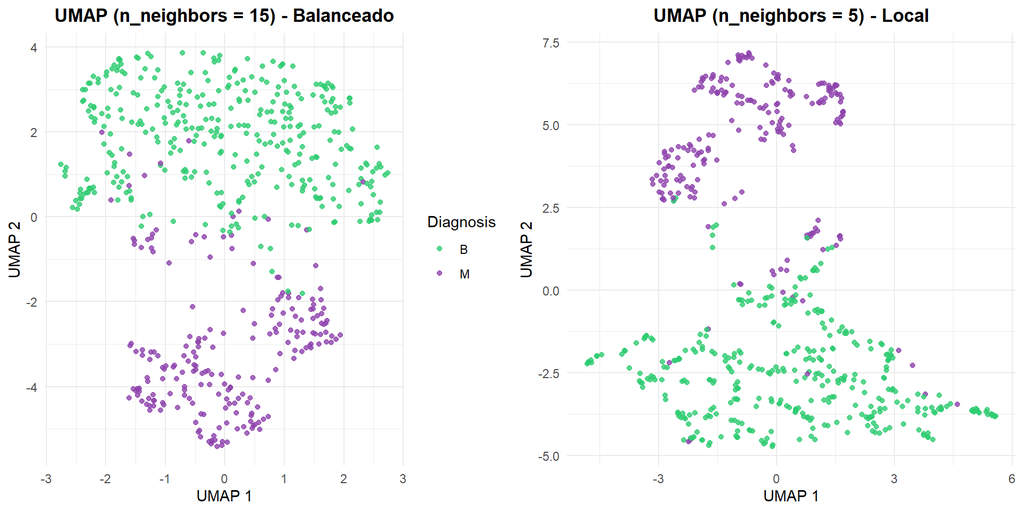

# 4. Decisiones Metodológicas

## Preprocesamiento

Se aplicó un escalado estándar al igual que al enfocar el lente de una cámara, necesitamos que todas las variables tengan la misma escala lumínica para que variables con valores numéricos altos no opaquen a las pequeñas

Selección de parámetros n_neighbors = 15: Balancea el enfoque entre la estructura local y la global

min_dist = 0.1: Controla cuán juntos se agrupan los puntos un valor bajo permite ver clústeres bien definidos y densos

# 5. Interpretación de Resultados

Al evaluar las proyecciones generadas, podemos observar cómo UMAP revela la estructura oculta de los datos celulares desde distintas perspectivas:

Al usar n_neighbors = 5, el algoritmo actúa como un lente macro, enfocándose estrictamente en la estructura local. Esto provoca que los datos se vean más dispersos y fragmentados en pequeños subgrupos, perdiendo un poco el contexto general.

La configuración balanceada n_neighbors = 15 ofrece una separación óptima y natural, donde se distingue claramente la frontera entre las células sanas y las cancerosas sin perder los matices internos de cada grupo.

# 6. Conclusión

La aplicación de UMAP al dataset Breast Cancer Wisconsin demuestra que es un algoritmo muy intuitivo y capaz para desenredar conjuntos médicos de alta dimensionalidad.

A través de la comparación visual directa de dos configuraciones distintas, se comprobó que el algoritmo permite decidir qué tanta relevancia se le da al panorama global frente al detalle microscópico. En conclusión, el modelo balanceado logró una representación sumamente nítida de la naturaleza biológica de los tumores, separando exitosamente los diagnósticos sin necesidad de conocerlos previamente.

# 2.4 Independent Component Analysis (ICA)

El Análisis de Componentes Independientes (ICA) es un método de aprendizaje no supervisado cuyo objetivo es separar un conjunto de señales observadas en componentes estadísticamente independientes. A diferencia de PCA o SVD, que buscan maximizar varianza y producen componentes no correlacionados, ICA busca identificar fuentes subyacentes que sean independientes entre sí desde el punto de vista estadístico (Hyvärinen & Oja, 2000).

## 1. Objetivo

El objetivo de esta sección es aplicar el algoritmo de Análisis de Componentes Independientes (ICA) a señales biomédicas reales para extraer fuentes de información ocultas que se encuentran mezcladas en los datos observados.

## 2. Descripción del Dataset

Se seleccionó el conjunto de datos de señales biomédicas EEG During Mental Arithmetic Tasks. Este dataset contiene grabaciones de electroencefalogramas (EEG) de sujetos en formato .edf. Para este análisis, utilizaremos la grabación Subject00_2.edf, la cual captura la actividad eléctrica cerebral del sujeto número 00 mientras realizaba una tarea de cálculo mental intensivo este estado activo es ideal, ya que genera una mezcla compleja de concentración cerebral, parpadeos y tensión muscular.

## 3. Implementación

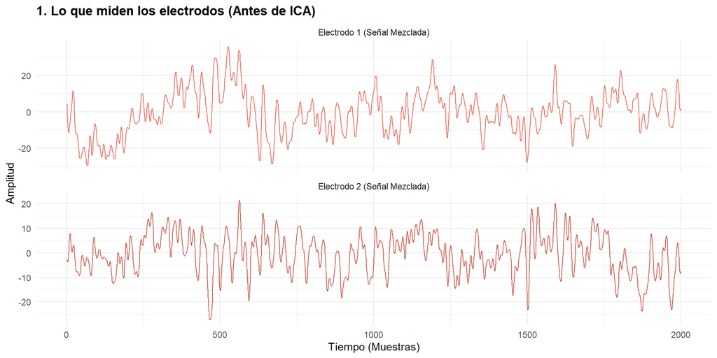

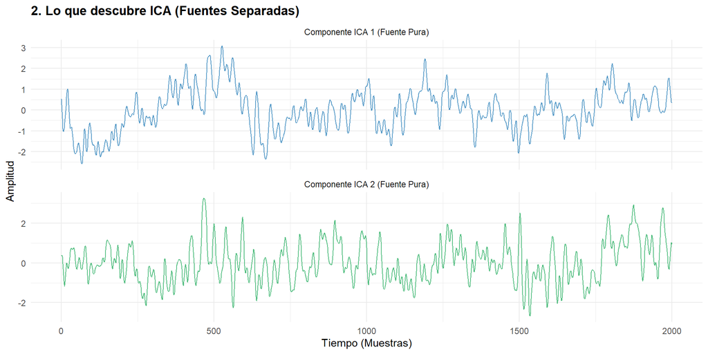

## 4. Decisiones Metodológicas

Preprocesamiento y Parámetros

Lectura de datos en crudo: Se utilizó directamente la señal sin filtros pasa-banda previos para permitir que ICA hiciera el trabajo pesado de encontrar las fuentes crudas.

Algoritmo fastICA: Se implementó utilizando la función no cuadrática logcosh. Número de componentes (n.comp = 2): Dado que extrajimos la señal de dos sensores físicos, matemáticamente podemos extraer un máximo de dos fuentes independientes.

## 5. Interpretación de Resultados

Al analizar los gráficos generados:

## 6. Conclusión

A diferencia de otros algoritmos de aprendizaje no supervisado que buscan similitudes o agrupan datos estáticos, ICA destaca al analizar señales en el tiempo buscando independencia estadística pura. En esta práctica, comprobamos que el algoritmo fue capaz de tomar lecturas biomédicas confusas y limpiar la imagen extrayendo las fuentes originales subyacentes sin tener ningún conocimiento previo de cómo se generaron.

## Comparación general

Más que comparar los algoritmos únicamente por su naturaleza matemática, resulta más pertinente analizarlos según el tipo de problema que buscan resolver dentro del análisis de datos. Ahora bien SVD se orienta a la representación eficiente y estructural de la información, ya que su objetivo principal es comprimir datos preservando la mayor cantidad posible de contenido relevante. Esto lo convierte en una herramienta especialmente útil en sistemas de recomendación y en problemas donde la aproximación matricial óptima es prioritaria.

Ahora t-SNE y UMAP están diseñados principalmente para la exploración visual de datos de alta dimensión, generando proyecciones bidimensionales que facilitan la identificación de agrupamientos y patrones ocultos, sin centrarse en la reconstrucción exacta de la matriz original. Siempre que ICA responde a una necesidad distinta, ya que busca recuperar fuentes subyacentes estadísticamente independientes a partir de señales mezcladas, lo que lo hace particularmente valioso en el procesamiento de señales biomédicas y de audio. Estos algoritmos no compiten directamente entre sí, sino que cumplen funciones complementarias según el objetivo específico del análisis.

## Ventajas y desventajas

Ventajas

Los algoritmos SVD, t-SNE, UMAP e ICA presentan ventajas importantes dentro del aprendizaje no supervisado, ya que permiten analizar datos desde diferentes enfoques. SVD ofrece una base matemática sólida y estable para reducir dimensionalidad con mínima pérdida de información, siendo ideal para compresión y extracción de características. t-SNE destaca por su capacidad para generar visualizaciones claras y separar clusters de forma efectiva en espacios de baja dimensión. UMAP mejora este enfoque al equilibrar la preservación de estructura local y global, además de ser más eficiente en grandes volúmenes de datos. Por su parte, ICA permite recuperar señales independientes subyacentes, lo que resulta especialmente útil en procesamiento de señales biomédicas y análisis de fuentes ocultas.

Desventajas

A pesar de sus fortalezas, cada algoritmo presenta limitaciones. SVD, al ser un método lineal, no captura relaciones no lineales complejas presentes en muchos conjuntos de datos modernos. t-SNE es altamente sensible a la selección de parámetros y no conserva adecuadamente la estructura global del conjunto de datos. UMAP también depende fuertemente de sus parámetros y puede resultar menos interpretable en algunos contextos. En el caso de ICA, sus supuestos estadísticos estrictos y su sensibilidad al ruido pueden afectar la calidad de los resultados cuando los datos no cumplen las condiciones ideales.

## Conclusiones

Los algoritmos SVD, t-SNE, UMAP e ICA cumplen funciones distintas dentro del aprendizaje no supervisado. SVD es una técnica sólida y matemática para reducir dimensionalidad y comprimir datos, aunque se limita a relaciones lineales. t-SNE y UMAP se enfocan en la visualización de datos de alta dimensión, permitiendo identificar agrupamientos; t-SNE destaca en la separación visual de clusters, mientras que UMAP ofrece mejor equilibrio entre estructura local y global y mayor eficiencia en grandes datasets. Por su parte, ICA busca recuperar fuentes independientes subyacentes, siendo especialmente útil en procesamiento de señales.

En conjunto, estos métodos no compiten, sino que se complementan según el objetivo del análisis: compresión, visualización o separación de señales.

## Referencias

Eckart, C., & Young, G. (1936).

The approximation of one matrix by another of lower rank.

Psychometrika, 1(3), 211–218. https://doi.org/10.1007/BF02288367

Golub, G. H., & Van Loan, C. F. (2013).

Matrix Computations (4th ed.). Johns Hopkins University Press.

van der Maaten, L., & Hinton, G. (2008).

Visualizing data using t-SNE. Journal of Machine Learning Research, 9, 2579–2605.

McInnes, L., Healy, J., & Melville, J. (2018).

UMAP: Uniform manifold approximation and projection for dimension reduction.

arXiv preprint arXiv:1802.03426.

Hyvärinen, A., & Oja, E. (2000).

Independent component analysis: Algorithms and applications.

Neural Networks, 13(4–5), 411–430.

https://doi.org/10.1016/S0893-6080(00)00026-5